# Solutions

POSC 459 — Social Welfare Politics and Policy · Week 15, Monday 7 December 2026

*Accessible text version of the Week 15 Monday slides — same content in linear order, with no slide-scaling container. Each image carries a text description. Readings: Howard 2007, ch. 10; Campbell 2014, ch. 6; Desmond 2023, chs. 7–8 (recommended: ch. 9 and the Epilogue).*

[figure not shown]

Readings: Howard, ch. 10; Campbell, ch. 6; Desmond, chs. 7–8

*Photo: Johnson signs the Economic Opportunity Act, Aug. 20, 1964 · Cecil Stoughton, White House · LBJ Library*

## First, ten minutes for the research post-survey

uci.questionpro.com/t/Acs2vZ9boh

- Scan the code, or type the address
- It’s the second half of the study you began on September 2
- It’s voluntary, and there’s no credit either way
- Absent today? It stays open through **Saturday 12/12**

[figure not shown]

## Today: three fixes for poverty, then you pick one

1. Four questions we asked all semester
2. Howard: programs grew, but poverty didn’t fall
3. Campbell: program rules trap families
4. Desmond: poverty persists because others benefit
5. Three corners: stand with the fix you’d back
6. The CSU–OpenAI contract: one last poll

## Four questions we asked all semester

| Question | What it asks | Where |
| --- | --- | --- |
| **Who can see it?** | Is the help a visible check, or hidden in the tax code? | Week 1 |
| **Who deserves it?** | Whom does the public think has earned help? | Week 12, Gilens |
| **Who benefits?** | Who gains from things as they are? | Week 3, Desmond |
| **Who defends it?** | Once a program exists, who fights to keep it? | Week 4, Pierson |

Today’s question: **what should change, and who has to give something up?**

## Howard: programs grew, but poverty didn’t fall

**“There has been change, yes, but not much progress”**

*Christopher Howard, ch. 10, p. 197*

- U.S. poverty rate: **11.2%** in 1974 (a recession year), **12.7%** in 2004 (no recession)
- Before taxes and benefits, U.S. income inequality is lower than in Belgium, France, or the U.K.
- After taxes and benefits, it is higher. Howard: “the result of political decisions”

*Howard 2007, ch. 10, pp. 193–94*

## Tax breaks for the better-off nearly match all aid to the poor

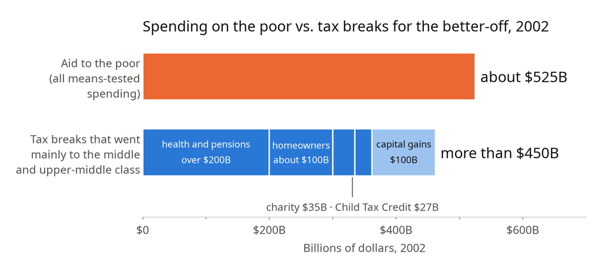

Biggest homeowner tax break, the mortgage interest deduction: taxpayers under $30,000 got **2%** of it; over half went to those over $100,000 (mid-2000s)

*Chart: Howard 2007, pp. 205–6 · mortgage deduction p. 205*

## Why so little progress? Howard sees four barriers

1. States run many programs, and benefits vary by state
2. The poor vote less, so officials hear them less
3. Voters aren’t asking for redistribution (chart below)
4. Tax breaks tilt toward the middle class and up

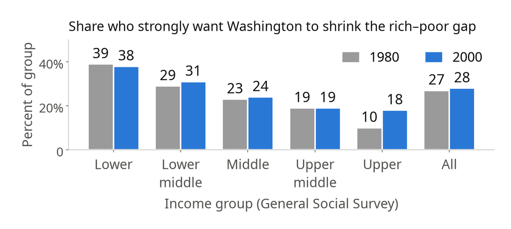

*Chart: Howard 2007, table 10.1, p. 199 (General Social Survey) · pp. 197–203*

## Howard’s fix: aim the help at people who need it

Four changes he proposes:

- Use tax **credits**, not deductions, and make them refundable, so people who owe no tax still get the money
- Phase out tax breaks for high incomes
- Set national minimum standards for programs the states run
- Require employers to provide benefits, the way they must pay the minimum wage

His goal: programs that are “truly inclusive … (much like Social Security)”

*Howard 2007, pp. 198, 207, 209*

## Campbell (Week 9): the programs’ own rules trap families

**“keep a boot on their throats”**

*Andrea Campbell, on means-tested programs, ch. 4, p. 70*

Three ways the rules trap people:

- Aid is kept worse than the worst job (the old “less eligibility” rule, p. 57)
- Earn more, lose benefits: a parent going from $10,000 to $40,000 keeps 45 cents of each added dollar, or as little as 20 (her 2014 example, p. 64)
- Every state has different rules: “fifty different worlds” (ch. 5)

## Campbell’s fix: the same protection for everyone

**“Social insurance doesn’t work if it isn’t truly social”**

*Andrea Campbell, ch. 6, p. 117*

- Health care and long-term care for all; Germany’s care insurance costs a **1.95%** payroll tax (pp. 115–18)
- Paid leave and child care, so parents can work (pp. 121–23)
- The same help in every state (pp. 124, 130)
- Pay for it: U.S. taxes are **3rd-lowest** of 34 OECD nations (p. 129)

## Desmond: ending poverty costs less than unpaid taxes

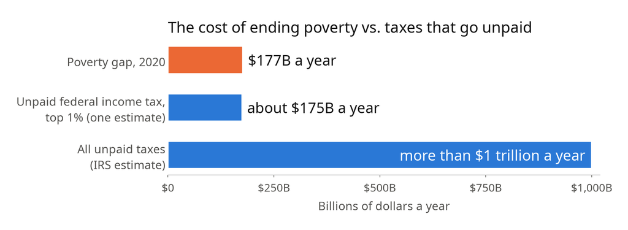

Poverty gap: what it would take to lift everyone below the poverty line up to it, 2020. Desmond: “less than 1 percent of our GDP”

*Chart: Desmond 2023, ch. 7, endnotes 12–14, 34 · ebook copy, no print pages*

## Desmond: more aid to the poor, less to the rich

His case that it works, Emergency Rental Assistance:

- In the pandemic, Washington spent **$46.5 billion** helping renters
- Eviction filings fell well below normal (chart)
- Few cheered, and the program ended
- Desmond: most aid today is “something like dialysis,” making poverty less deadly, not gone

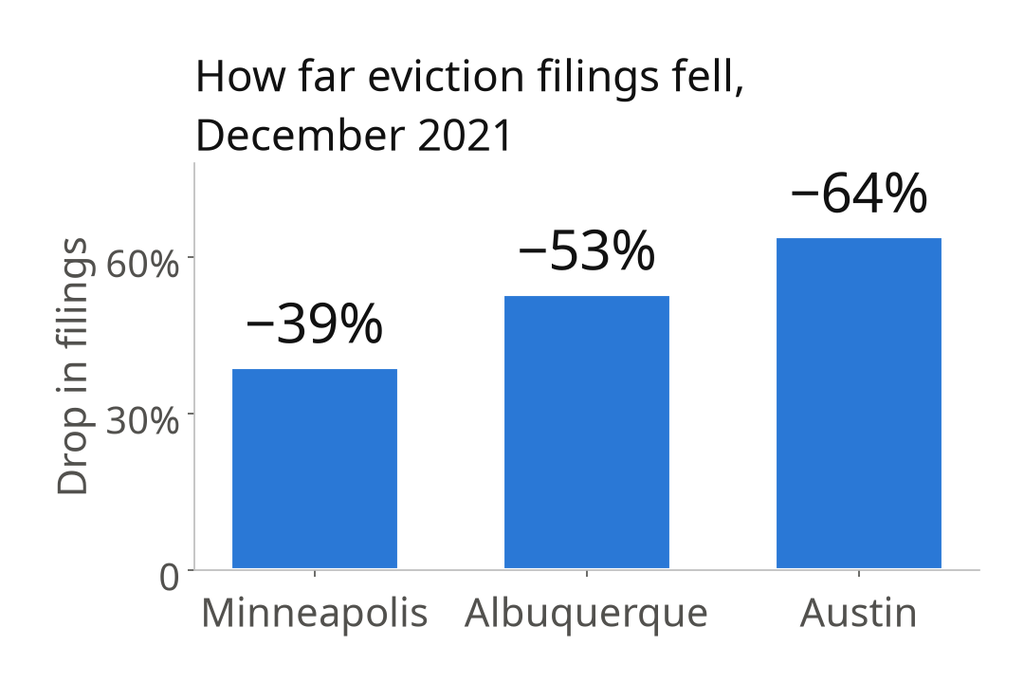

*Desmond 2023, ch. 7, endnotes 26, 28–31, 35 · ebook copy, no print pages*

## Desmond: give poor people more choices, so they can’t be exploited

“Choice is the antidote for exploitation.” (Desmond, ch. 8) What he proposes:

| Choice in | Desmond’s proposals |
| --- | --- |
| **Work** | Raise the $7.25 federal minimum wage and end the $2.13 minimum for tipped workers. Let workers bargain for a whole industry at once |
| **Housing** | Build more public housing. Help tenants buy their buildings as co-ops. Back small mortgages, as USDA’s rural loans already do |
| **Banking** | End steep overdraft fees. Make payday lenders show what a loan will cost |
| **Family** | Make birth control easy to get. Delaware did, and unintended pregnancies among low-income and uninsured women fell **24%**, 2014–17 |
| **Your own life** | “Conducting an audit of our lives”: where we shop, invest, work, and study |

*Desmond 2023, ch. 8, endnotes 1, 6, 10–14, 18–20, 24, 27–30 · ebook copy, no print pages*

## Desmond: end the zoning rules that keep the poor out

- Many well-off places ban apartments and small homes (“exclusionary zoning”)
- His fix: lift those bans, and require new buildings to include affordable units
- New Jersey’s courts made more than **340** towns build affordable housing
- 1970: Nixon’s housing secretary, George Romney, proposed cutting federal money to towns that kept the poor out. Nixon killed it

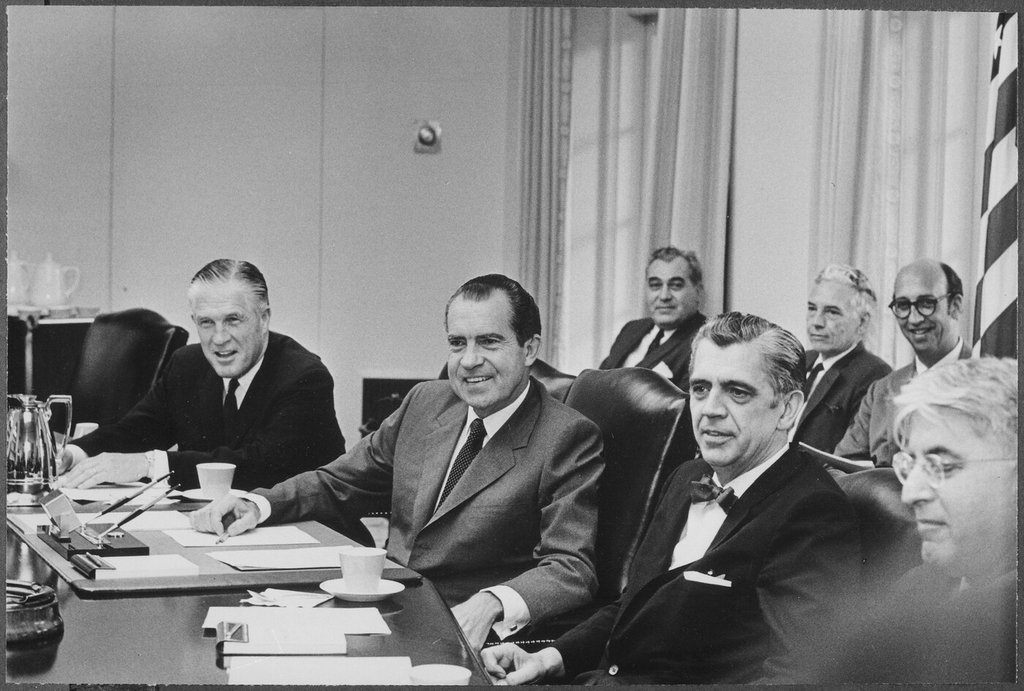

*Nixon cabinet meeting with George Romney, June 23, 1969 · Jack E. Kightlinger, White House · Nixon Library, NARA*

*Desmond 2023, ch. 9 and Epilogue (recommended), endnotes 9, 11 · ebook copy, no print pages*

## Three corners: stand with the author whose fix you’d back

1. Stand up and go to the corner I point to for Howard, Campbell, or Desmond. Choose the fix, not the chapter you liked
2. With the people in your corner, take **8 minutes** to write two sentences:
   - What is wrong, as your author sees it
   - What should be done about it
3. Pick one reporter. At **1:51** each reporter reads the two sentences aloud

## What each author says is wrong, and how to fix it

|  | What is wrong | The fix |
| --- | --- | --- |
| **Howard** | Tax breaks go mostly to the middle class and up, states keep benefits uneven, and the poor have little political voice (pp. 197–206) | Turn tax breaks into refundable credits, set national minimum standards, and make programs “truly inclusive” (pp. 198, 207, 209) |
| **Campbell** | Families must stay poor to get care, and the help they get depends on their state (pp. 118, 124, 130) | Cover everyone, as Germany does for long-term care; add paid leave and child care; pay with taxes that would still be low (pp. 116–18, 121–23, 129) |
| **Desmond** | Poverty lasts because people who aren’t poor benefit from it (ch. 7) | Make the rich pay their taxes, give the poor more choices, and end segregation (chs. 7–9) |

**1:51:** each corner’s reporter reads its two sentences, about two minutes per corner

## Round two: what would your fix need to work?

Stay in your corner. **One minute** to talk, then one answer per corner:

1. What does another corner get right that yours misses?
2. Desmond says people who aren’t poor benefit from poverty. Howard says voters aren’t asking for redistribution. **Does your fix need a fight, or persuasion?**
3. Who has to give something up for your fix to work?

[figure not shown]

*Poor People’s March, Washington, June 18, 1968 · Warren K. Leffler, U.S. News & World Report · Library of Congress*

## Last poll: does getting something make you defend it?

The case: the CSU’s contract for ChatGPT Edu, which you all have

- The CSU paid OpenAI **$17 million** for the first 18 months (2025) and renewed for **$13 million a year** for three years (2026)
- Who was in the room when it was signed? Has any group of users organized?
- Compare AARP (Week 14): it claims 35 million members, but only one in six joined for its politics

**Poll, same as Week 2: Does receiving something make you more likely to defend the decision that provided it?** Hands up for yes.

Hands for yes in Week 2: **___** · Today: **___**

*EdSource, May 21, 2026 · Howard 2007, ch. 7, pp. 127, 135*

## Wednesday is review; the final is Monday, December 14

**Wed 12/9:** final exam review, in class

**Wed 12/9, 11:59 p.m.:** Reading Journal, your second five entries (ten in all)

**Sat 12/12:** the post-survey closes

**Mon 12/14, 1:00–2:50, GH 305:** final exam, written by hand. Bring a blue book

## By 2:15 you should be able to say

Howard: programs grew, poverty didn’t fall, and the tax breaks favor the better-off

Campbell: the rules trap the poor; the same protection for everyone would free them

Desmond: poverty lasts because others benefit, and unpaid taxes could pay to end it

Your corner’s fix, and who would have to give something up for it

Whether a semester changed your answer to the poll